# Domaći zadatak 1 - Data Story

Da li kasnjenje pri polasku predviđa kasnjenje pri dolasku - i koji su najgori krivci?

Masa Uzelac RN 40/22

2026-04-23

```r
library(nycflights13)
library(tidyverse)
library(scales)
library(ggridges)
library(patchwork)
library(knitr)
library(kableExtra)
```

# 1. Uvod

## Istraživačko pitanje

> **Da li kasnjenje pri polasku statistički značajno predviđa kasnjenje pri dolasku, i razlikuju li se avio-kompanije međusobno po prosečnom kašnjenju pri dolasku?**

## Zašto je ovo pitanje zanimljivo?

Svako ko je ikad sedio u avionu koji “čeka na pisti” zna da osećaj panike - “hoću li stići na transfer?”. Intuicija govori da kasnjenje pri polasku direktno uzrokuje kasnjenje pri dolasku, ali je li to stvarno tako? I ako jeste - koliko? Da li avioni “nadoknađuju” izgubljeno vreme u vazduhu?

Drugi deo pitanja je praktičniji: ako odgovor bude “da, kasnjenje se prenosi”, koje avio-kompanije su najgori krivci? Ako odgovor bude “ne, kasnjenja se nadoknađuju”, onda kasnjenje pri polasku nije toliki problem.

- **Ako odgovor bude “da”** - putnici bi trebali aktivno birati kompanije sa manjim kašnjenjem pri polasku.
- **Ako odgovor bude “ne”** - kasnjenje pri polasku je neugodan ali ne i katastrofalan signal za putnika.

# 2. Istraživanje podataka

## Upoznavanje sa datasetom

```r
# Dimenzije i struktura
glimpse(flights)
```

```
## Rows: 336,776
## Columns: 19
## $ year           <int> 2013, 2013, 2013, 2013, 2013, 2013, 2013, 2013, 2013, 2…
## $ month          <int> 1, 1, 1, 1, 1, 1, 1, 1, 1, 1, 1, 1, 1, 1, 1, 1, 1, 1, 1…
## $ day            <int> 1, 1, 1, 1, 1, 1, 1, 1, 1, 1, 1, 1, 1, 1, 1, 1, 1, 1, 1…
## $ dep_time       <int> 517, 533, 542, 544, 554, 554, 555, 557, 557, 558, 558, …
## $ sched_dep_time <int> 515, 529, 540, 545, 600, 558, 600, 600, 600, 600, 600, …
## $ dep_delay      <dbl> 2, 4, 2, -1, -6, -4, -5, -3, -3, -2, -2, -2, -2, -2, -1…
## $ arr_time       <int> 830, 850, 923, 1004, 812, 740, 913, 709, 838, 753, 849,…
## $ sched_arr_time <int> 819, 830, 850, 1022, 837, 728, 854, 723, 846, 745, 851,…
## $ arr_delay      <dbl> 11, 20, 33, -18, -25, 12, 19, -14, -8, 8, -2, -3, 7, -1…
## $ carrier        <chr> "UA", "UA", "AA", "B6", "DL", "UA", "B6", "EV", "B6", "…
## $ flight         <int> 1545, 1714, 1141, 725, 461, 1696, 507, 5708, 79, 301, 4…
## $ tailnum        <chr> "N14228", "N24211", "N619AA", "N804JB", "N668DN", "N394…
## $ origin         <chr> "EWR", "LGA", "JFK", "JFK", "LGA", "EWR", "EWR", "LGA",…
## $ dest           <chr> "IAH", "IAH", "MIA", "BQN", "ATL", "ORD", "FLL", "IAD",…
## $ air_time       <dbl> 227, 227, 160, 183, 116, 150, 158, 53, 140, 138, 149, 1…
## $ distance       <dbl> 1400, 1416, 1089, 1576, 762, 719, 1065, 229, 944, 733, …
## $ hour           <dbl> 5, 5, 5, 5, 6, 5, 6, 6, 6, 6, 6, 6, 6, 6, 6, 5, 6, 6, 6…
## $ minute         <dbl> 15, 29, 40, 45, 0, 58, 0, 0, 0, 0, 0, 0, 0, 0, 0, 59, 0…
## $ time_hour      <dttm> 2013-01-01 05:00:00, 2013-01-01 05:00:00, 2013-01-01 0…
```

Dataset `nycflights13::flights` sadrži **336.776 letova** iz tri njujorška aerodroma (JFK, LGA, EWR) tokom 2013. godine, sa 19 varijabli.

Za naše pitanje, relevantne varijable su:

| Varijabla | Opis |
| --- | --- |
| `dep_delay` | Kasnjenje pri polasku (min); negativno = ranije |
| `arr_delay` | Kasnjenje pri dolasku (min); negativno = ranije |
| `carrier` | Kod avio-kompanije (2 slova) |
| `origin` | Polazni aerodrom |

```r
flights %>%
  select(dep_delay, arr_delay, carrier, origin) %>%
  filter(!is.na(dep_delay), !is.na(arr_delay)) %>%
  summarise(
    n              = n(),
    dep_mean       = mean(dep_delay),
    dep_median     = median(dep_delay),
    dep_sd         = sd(dep_delay),
    dep_na         = sum(is.na(dep_delay)),
    arr_mean       = mean(arr_delay),
    arr_median     = median(arr_delay),
    arr_sd         = sd(arr_delay)
  ) %>%
  kable(
    col.names = c("N letova", "Avg dep delay", "Med dep delay",
                  "SD dep delay", "NA dep", "Avg arr delay",
                  "Med arr delay", "SD arr delay"),
    digits = 2,
    caption = "Deskriptivna statistika kašnjenja (minutama)"
  ) %>%
  kable_styling(bootstrap_options = c("striped", "hover", "condensed"))
```

Deskriptivna statistika kašnjenja (minutama)

| N letova | Avg dep delay | Med dep delay | SD dep delay | NA dep | Avg arr delay | Med arr delay | SD arr delay |
| --- | --- | --- | --- | --- | --- | --- | --- |
| 327346 | 12.56 | -2 | 40.07 | 0 | 6.9 | -5 | 44.63 |

Šta primećujemo?

Prosečno kašnjenje pri polasku iznosi oko 12.6 minuta, dok je kašnjenje pri dolasku nešto manje - oko 6.9 minuta. Zanimljivo je da su medijane (srednje vrednosti koje nisu podložne ekstremima) znatno niže ili čak negativne (-2 i -5), što nam govori da većina letova zapravo polazi i stiže malo ranije, ali mali broj letova sa ogromnim kašnjenjima (vidimo visoku standardnu devijaciju) značajno kvari prosek.

```r
# Proseci po avio-kompaniji, spojeni sa imenima
flights %>%
  filter(!is.na(arr_delay), !is.na(dep_delay)) %>%
  left_join(airlines, by = "carrier") %>%
  group_by(carrier, name) %>%
  summarise(
    n             = n(),
    avg_dep_delay = mean(dep_delay),
    avg_arr_delay = mean(arr_delay),
    pct_on_time   = mean(arr_delay <= 0) * 100,
    .groups = "drop"
  ) %>%
  arrange(desc(avg_arr_delay)) %>%
  kable(
    col.names = c("Kod", "Kompanija", "N letova",
                  "Avg polazak (min)", "Avg dolazak (min)", "% na vreme"),
    digits    = 1,
    caption   = "Prosečna kašnjenja po avio-kompaniji (sortirano po dolasku)"
  ) %>%
  kable_styling(bootstrap_options = c("striped", "hover", "condensed")) %>%
  row_spec(1:3, background = "#fde8e8")   # Top 3 najgori - crvenkasto
```

Prosečna kašnjenja po avio-kompaniji (sortirano po dolasku)

| Kod | Kompanija | N letova | Avg polazak (min) | Avg dolazak (min) | % na vreme |
| --- | --- | --- | --- | --- | --- |
| F9 | Frontier Airlines Inc. | 681 | 20.2 | 21.9 | 42.4 |
| FL | AirTran Airways Corporation | 3175 | 18.6 | 20.1 | 40.3 |
| EV | ExpressJet Airlines Inc. | 51108 | 19.8 | 15.8 | 52.1 |
| YV | Mesa Airlines Inc. | 544 | 18.9 | 15.6 | 52.6 |
| OO | SkyWest Airlines Inc. | 29 | 12.6 | 11.9 | 65.5 |
| MQ | Envoy Air | 25037 | 10.4 | 10.8 | 53.3 |
| WN | Southwest Airlines Co. | 12044 | 17.7 | 9.6 | 56.0 |
| B6 | JetBlue Airways | 54049 | 13.0 | 9.5 | 56.3 |
| 9E | Endeavor Air Inc. | 17294 | 16.4 | 7.4 | 61.6 |
| UA | United Air Lines Inc. | 57782 | 12.0 | 3.6 | 61.5 |
| US | US Airways Inc. | 19831 | 3.7 | 2.1 | 62.9 |
| VX | Virgin America | 5116 | 12.8 | 1.8 | 65.9 |
| DL | Delta Air Lines Inc. | 47658 | 9.2 | 1.6 | 65.6 |
| AA | American Airlines Inc. | 31947 | 8.6 | 0.4 | 66.5 |
| HA | Hawaiian Airlines Inc. | 342 | 4.9 | -6.9 | 71.6 |
| AS | Alaska Airlines Inc. | 709 | 5.8 | -9.9 | 73.3 |

## Vizualizacija 1 - Raspodela kašnjenja (dep vs arr)

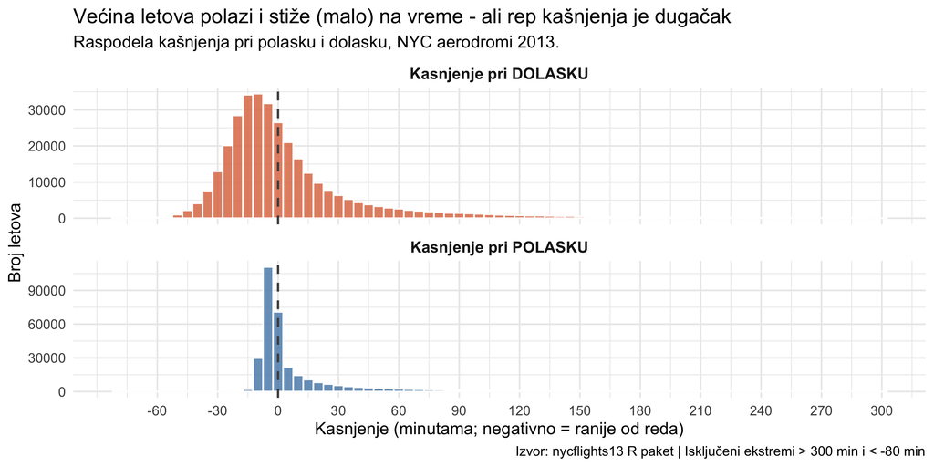

```r
# Pripremamo "tidy" format za dual histogram
kasnjenja_long <- flights %>%
  filter(!is.na(dep_delay), !is.na(arr_delay),
         dep_delay > -60, dep_delay < 300,    # uklanjamo ekstremne outlajere
         arr_delay > -80, arr_delay < 300) %>%
  pivot_longer(cols = c(dep_delay, arr_delay),
               names_to  = "tip",
               values_to = "kasnjenje") %>%
  mutate(tip = recode(tip,
                      dep_delay = "Kasnjenje pri POLASKU",
                      arr_delay = "Kasnjenje pri DOLASKU"))

ggplot(kasnjenja_long, aes(x = kasnjenje, fill = tip)) +
  geom_histogram(binwidth = 5, color = "white", alpha = 0.85) +
  geom_vline(xintercept = 0, linetype = "dashed", color = "gray30", linewidth = 0.8) +
  facet_wrap(~tip, ncol = 1, scales = "free_y") +
  scale_fill_manual(values = c("#e07b54", "#5b8db8"), guide = "none") +
  scale_x_continuous(breaks = seq(-60, 300, 30)) +
  labs(
    title    = "Većina letova polazi i stiže (malo) na vreme - ali rep kašnjenja je dugačak",
    subtitle = "Raspodela kašnjenja pri polasku i dolasku, NYC aerodromi 2013.",
    x        = "Kasnjenje (minutama; negativno = ranije od reda)",
    y        = "Broj letova",
    caption  = "Izvor: nycflights13 R paket | Isključeni ekstremi > 300 min i < -80 min"
  ) +
  theme_minimal(base_size = 13) +
  theme(strip.text = element_text(face = "bold", size = 12))
```

## Vizualizacija 2 - Ko su najgori krivci?

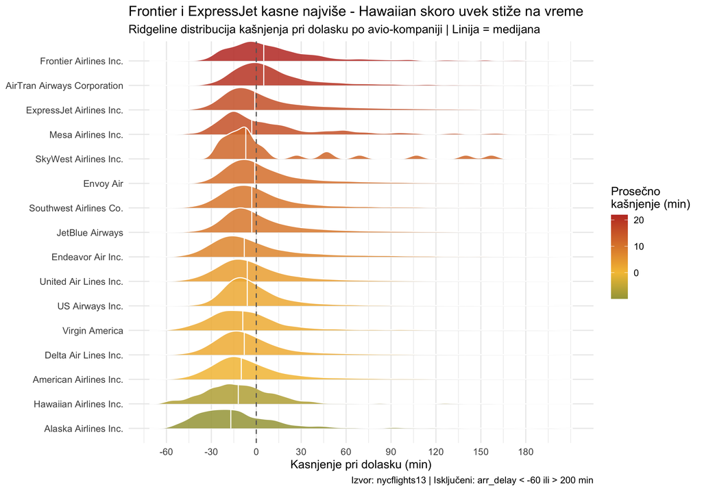

```r
# Proseci po kompaniji + ridgeline distribucija
avg_po_kompaniji <- flights %>%
  filter(!is.na(arr_delay)) %>%
  left_join(airlines, by = "carrier") %>%
  group_by(name) %>%
  summarise(avg = mean(arr_delay), .groups = "drop")

flights %>%
  filter(!is.na(arr_delay), arr_delay > -60, arr_delay < 200) %>%
  left_join(airlines, by = "carrier") %>%
  left_join(avg_po_kompaniji, by = "name") %>%
  mutate(name = fct_reorder(name, avg)) %>%
  ggplot(aes(x = arr_delay, y = name, fill = avg)) +
  geom_density_ridges(
    alpha = 0.85, scale = 1.3,
    quantile_lines = TRUE, quantiles = 2,
    color = "white"
  ) +
  geom_vline(xintercept = 0, linetype = "dashed", color = "gray40") +
  scale_fill_gradient2(
    low      = "#3a7d44",
    mid      = "#f5c242",
    high     = "#c0392b",
    midpoint = 0,
    name     = "Prosečno\nkašnjenje (min)"
  ) +
  scale_x_continuous(breaks = seq(-60, 200, 30)) +
  labs(
    title    = "Frontier i ExpressJet kasne najviše - Hawaiian skoro uvek stiže na vreme",
    subtitle = "Ridgeline distribucija kašnjenja pri dolasku po avio-kompaniji | Linija = medijana",
    x        = "Kasnjenje pri dolasku (min)",
    y        = NULL,
    caption  = "Izvor: nycflights13 | Isključeni: arr_delay < -60 ili > 200 min"
  ) +
  theme_minimal(base_size = 12) +
  theme(legend.position = "right")
```

# 3. Provera pretpostavki

Da bismo testirali razlike između kompanija, koristićemo `arr_delay` kao zavisnu varijablu i `carrier` kao grupu.

## Histogram po grupama

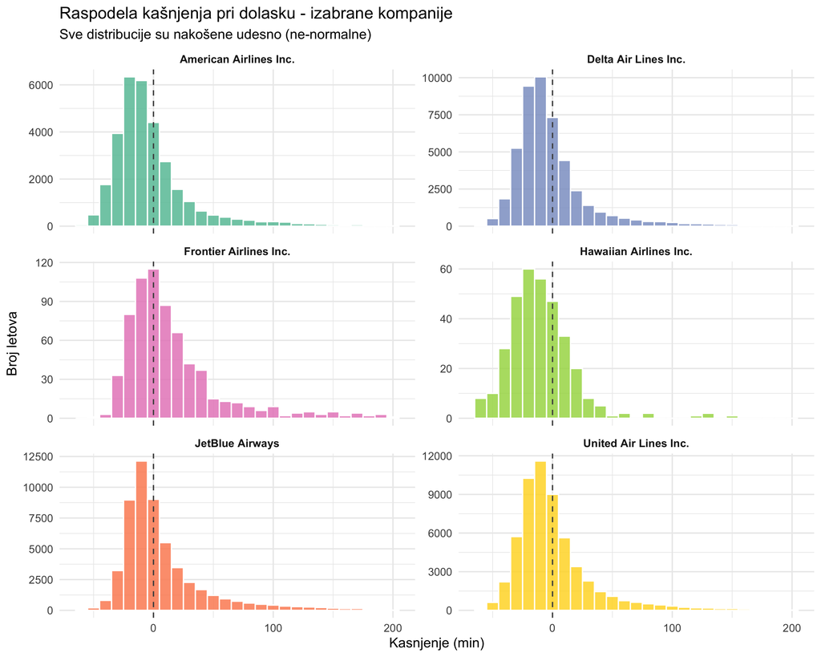

```r
# biramo 6 "interesantnih" kompanija
odabrane <- c("UA", "AA", "DL", "B6", "F9", "HA")

flights %>%
  filter(carrier %in% odabrane, !is.na(arr_delay),
         arr_delay > -60, arr_delay < 200) %>%
  left_join(airlines, by = "carrier") %>%
  ggplot(aes(x = arr_delay, fill = carrier)) +
  geom_histogram(binwidth = 10, color = "white", alpha = 0.85) +
  geom_vline(xintercept = 0, linetype = "dashed", color = "gray30") +
  facet_wrap(~name, ncol = 2, scales = "free_y") +
  scale_fill_brewer(palette = "Set2", guide = "none") +
  labs(
    title    = "Raspodela kašnjenja pri dolasku - izabrane kompanije",
    subtitle = "Sve distribucije su nakošene udesno (ne-normalne)",
    x = "Kasnjenje (min)", y = "Broj letova"
  ) +
  theme_minimal(base_size = 12) +
  theme(strip.text = element_text(face = "bold"))
```

**Komentar:** Ni jedna raspodela ne liči na normalnu - sve su nakošene udesno sa dugim repom kašnjenja. Ovo već nagoveštava da ANOVA nije prikladan test.

## QQ plot po grupama

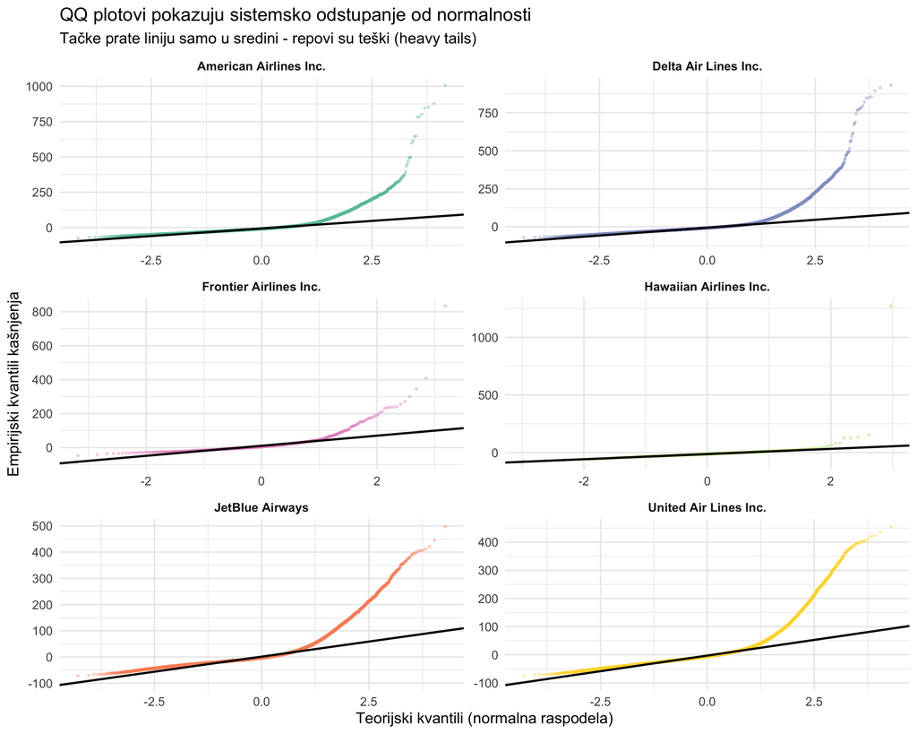

```r
flights %>%
  filter(carrier %in% odabrane, !is.na(arr_delay)) %>%
  left_join(airlines, by = "carrier") %>%
  ggplot(aes(sample = arr_delay, color = carrier)) +
  stat_qq(alpha = 0.3, size = 0.5) +
  stat_qq_line(color = "black", linewidth = 0.8) +
  facet_wrap(~name, ncol = 2, scales = "free") +
  scale_color_brewer(palette = "Set2", guide = "none") +
  labs(
    title    = "QQ plotovi pokazuju sistemsko odstupanje od normalnosti",
    subtitle = "Tačke prate liniju samo u sredini - repovi su teški (heavy tails)",
    x = "Teorijski kvantili (normalna raspodela)",
    y = "Empirijski kvantili kašnjenja"
  ) +
  theme_minimal(base_size = 12) +
  theme(strip.text = element_text(face = "bold"))
```

**Komentar:** QQ plotovi jasno pokazuju da tačke odstupaju od dijagonale, posebno u desnom repu - klasičan znak *heavy-tailed* (ne-normalne) raspodele.

## Shapiro-Wilk test

> **Napomena:** Shapiro-Wilk test je dizajniran za male uzorke (n < 5000). Kada imamo desetine hiljada opservacija, test će **uvek** biti statistički značajan - čak i za minimalna odstupanja koja su praktično beznačajna.

```r
# Koristimo nasumičan uzorak od 4999 letova po kompaniji (max za shapiro.test)
set.seed(42)

shapiro_rezultati <- flights %>%
  filter(carrier %in% odabrane, !is.na(arr_delay)) %>%
  group_by(carrier) %>%
  slice_head(n = 4999) %>%
  summarise(
    n       = n(),
    W       = shapiro.test(arr_delay)$statistic,
    p_value = shapiro.test(arr_delay)$p.value,
    .groups = "drop"
  ) %>%
  mutate(normalno = ifelse(p_value > 0.05, "✓ Da", "✗ Ne"))

shapiro_rezultati %>%
  kable(
    col.names = c("Kompanija", "N uzorka", "W statistika", "p-vrednost", "Normalnost?"),
    digits = 4,
    caption = "Shapiro-Wilk test normalnosti po kompaniji (uzorak ≤ 4999)"
  ) %>%
  kable_styling(bootstrap_options = c("striped", "hover")) %>%
  column_spec(5, bold = TRUE,
              color = ifelse(shapiro_rezultati$normalno == "✓ Da", "green", "red"))
```

Shapiro-Wilk test normalnosti po kompaniji (uzorak ≤ 4999)

| Kompanija | N uzorka | W statistika | p-vrednost | Normalnost? |
| --- | --- | --- | --- | --- |
| AA | 4999 | 0.7603 | 0 | ✗ Ne |
| B6 | 4999 | 0.7313 | 0 | ✗ Ne |
| DL | 4999 | 0.6750 | 0 | ✗ Ne |
| F9 | 681 | 0.6123 | 0 | ✗ Ne |
| HA | 342 | 0.2618 | 0 | ✗ Ne |
| UA | 4999 | 0.7409 | 0 | ✗ Ne |

## Zaključak o pretpostavkama

Sva tri dijagnostička alata (histogram, QQ plot, Shapiro-Wilk) jednoglasno pokazuju da **raspodele kašnjenja nisu normalne** - nakošene su udesno i imaju teške repove.

**Odluka:** Koristićemo **Kruskal-Wallis test** umesto ANOVA-e, jer je to neparametarski ekvivalent koji ne pretpostavlja normalnost. Kruskal-Wallis testira da li barem jedna grupa ima statistički različitu *centralnu tendenciju* (medijanu) od ostalih.

# 4. Analiza i glavni grafik

## 4a. Statistički test

### Kruskal-Wallis test - razlike između kompanija

```r
kruskal_rezultat <- kruskal.test(arr_delay ~ carrier, data = flights)
print(kruskal_rezultat)
```

```
##
##  Kruskal-Wallis rank sum test
##
## data:  arr_delay by carrier
## Kruskal-Wallis chi-squared = 8565, df = 15, p-value < 2.2e-16
```

**Interpretacija za nestatičara:** Postoji statistički veoma značajna razlika u kašnjenjima pri dolasku između avio-kompanija (p < 0.001) - toliko malo je verovatno da su ove razlike slučajne da bismo mogli da testiramo ovaj eksperiment milionima puta i skoro nikad ne bismo dobili ovakav rezultat *slučajno*. Drugim rečima, **izbor avio-kompanije zaista utiče na to koliko ćete kasniti**.

### Koliko kasnjenje pri polasku objašnjava kasnjenje pri dolasku?

```r
kor <- flights %>%
  filter(!is.na(dep_delay), !is.na(arr_delay)) %>%
  summarise(r = cor(dep_delay, arr_delay, method = "spearman"))

cat("Spearman korelacija dep_delay ~ arr_delay:", round(kor$r, 3))
```

```
## Spearman korelacija dep_delay ~ arr_delay: 0.626
```

## 4b. Glavni grafik

[figure not shown]

```r
# Kompletni podaci za sve kompanije
summary_podaci <- flights %>%
  filter(!is.na(arr_delay), !is.na(dep_delay)) %>%
  left_join(airlines, by = "carrier") %>%
  group_by(carrier, name) %>%
  summarise(
    n             = n(),
    avg_arr       = mean(arr_delay),
    med_arr       = median(arr_delay),
    avg_dep       = mean(dep_delay),
    pct_on_time   = mean(arr_delay <= 0) * 100,
    .groups = "drop"
  ) %>%
  mutate(
    # Skraćujemo dugačka imena kompanija
    kratko_ime = str_wrap(name, 15),
    kratko_ime = fct_reorder(kratko_ime, avg_arr)
  )

ggplot(summary_podaci,
       aes(x = kratko_ime, y = avg_arr, fill = avg_arr)) +
  geom_col(width = 0.75, color = "white", linewidth = 0.3) +
  geom_hline(yintercept = 0, color = "gray20", linewidth = 0.8) +
  geom_point(aes(y = med_arr), shape = 23,
             fill = "white", color = "gray20", size = 3) +
  # Anotacija proseka i medijane
  geom_text(aes(label = sprintf("%.1f", avg_arr),
                vjust = ifelse(avg_arr >= 0, -0.5, 1.3)),
            size = 3.5, fontface = "bold", color = "gray20") +
  # Veličina tačke = procenat na vreme
  scale_fill_gradient2(
    low      = "#2d6a4f",
    mid      = "#f4a261",
    high     = "#c0392b",
    midpoint = 5,
    name     = "Prosečno\nkašnjenje (min)"
  ) +
  scale_y_continuous(
    breaks = seq(-10, 25, 5),
    labels = function(x) paste0(ifelse(x >= 0, "+", ""), x, " min"),
    expand = expansion(mult = c(0.1, 0.2))
  ) +
  labs(
    title    = "Frontier i ExpressJet kasne skoro pola sata - Hawaiian dolazi ranije nego što piše",
    subtitle = "Prosečno kašnjenje pri dolasku po avio-kompaniji | ◇ = medijana kašnjenja\nNYC aerodromi (JFK, LGA, EWR), 2013. godina",
    x        = NULL,
    y        = "Prosečno kašnjenje pri dolasku (minutama)",
    caption  = paste0(
      "Izvor: nycflights13 R paket (CRAN) | N = ",
      format(sum(summary_podaci$n), big.mark = "."), " letova\n",
      "Kruskal-Wallis test: p < 0.001 - razlike između kompanija nisu slučajne"
    )
  ) +
  theme_minimal(base_size = 12) +
  theme(
    plot.title      = element_text(face = "bold", size = 14, lineheight = 1.2),
    plot.subtitle   = element_text(color = "gray40", size = 11),
    plot.caption    = element_text(color = "gray50", size = 9, hjust = 0),
    axis.text.x     = element_text(size = 9, lineheight = 1.1),
    panel.grid.major.x = element_blank(),
    legend.position = "right"
  ) +
  coord_flip()
```

# 5. Zaključak

## Šta ostaje otvoreno?

Ova analiza ima nekoliko ograničenja. Prvo, posmatramo samo **2013. godinu** iz samo **tri aerodroma** - rezultati možda nisu prenosivi na današnje letove ili na letove iz drugih vazdušnih prostora. Drugo, nismo kontrolisali za **dužinu rute**: Hawaiian Airlines leti pretežno duge transkontinentalne rute gde se kašnjenja lakše nadoknađuju, dok ExpressJet leti kratke regionalne rute sa manje “prostora za manevrisanje”. Treće, nismo razdvajali letove po **sezoni** - zimski meseci gotovo sigurno imaju drugačiji profil kašnjenja od letnjih. Sa više podataka, zanimljivo bi bilo istražiti da li su kašnjenja sistemska (npr. uvek iste kompanije u istim mesecima) ili stohastična, i koji faktori (aerodrom, sat poletanja, tip aviona) najviše doprinose ekstremnim kašnjenjima.